# p8451_assignment_7

2023-03-02

## Part 1: Data Cleaning

### Loading packages and preparing dataset

To proceed with the problem set, the following libraries will be used in addition to base R

```r
library(tidyverse)
```

```r
library(rpart)
library(rpart.plot)
library(pROC)
library(caret)
library(randomForest)
set.seed(123)
```

The data set was comprised of the 16 variables below:

- ID: identifier
- Age: age in initial MI (years)
- Sex: reported by patient
- Sodium: serum sodium (mmol/L)
- ALT: liver enzymes (IU/L)
- WBC: white blood cell count (billions/L)
- ESR: erythrocyte sedimentation rate
- SBP: systolic blood pressure at intake (mmHg)
- DBP: diastolic blood pressure at intake (mmHg)
- Pulm.adema: pulmonary adema (yes or no)
- FC: functional class of angina pectoris in the last year (no angina pectoris, I FC, II FC, III FC, IV FC)
- Arrythmia: prescence of arrythmia (yes or no)
- Diab: presence of diabetes (yes or no)
- Obesity: presence of obesity (yes or no)
- Asthma: presence of asthma (yes or no)
- Readmission: readmitted to hospital within 30 days (yes or no)

The data set was first imported using the `read_csv` function, and the `clean_names` function was used to tidy variable names. The `skim` function was then used to summarise the data set and observe the variable times. The `skim` function revealed that all 16 variables were numerical variables. Based off of the given codebook, the following variables were converted to factor variables:

- Sex (`sex`)
- Pulmonary adema (`pul_adema`)
- Functional class of angina pectoris (`fc`)
- Arrythmia (`arr`)
- Presence of diabetes (`diab`)
- Presence of obesity (`obesity`)
- Presence of asthma (`asthma`)
- Readmission (`readmission`)

Missing variables were then omitted using `na.omit` and the variables `id` and `sex` were dropped. The summary function was then used to check the balance of the data for the outcome of interest `readmission`.

```r
mi_data = read_csv(file = "data/mi.data.csv") %>%
  janitor::clean_names()
skimr::skim(mi_data)
```

Data summary

| Name | mi_data |
| --- | --- |
| Number of rows | 1700 |
| Number of columns | 16 |
| _______________________ |  |
| Column type frequency: |  |
| numeric | 16 |
| ________________________ |  |
| Group variables | None |

**Variable type: numeric**

| skim_variable | n_missing | complete_rate | mean | sd | p0 | p25 | p50 | p75 | p100 | hist |
| --- | --- | --- | --- | --- | --- | --- | --- | --- | --- | --- |
| id | 0 | 1 | 850.50 | 490.89 | 1.00 | 425.75 | 850.50 | 1275.25 | 1700.0 | ▇▇▇▇▇ |
| age | 0 | 1 | 61.87 | 11.24 | 26.00 | 54.00 | 63.00 | 70.00 | 92.0 | ▁▃▇▆▁ |
| sex | 0 | 1 | 0.63 | 0.49 | 0.00 | 0.00 | 1.00 | 1.00 | 2.0 | ▅▁▇▁▁ |
| sodium | 0 | 1 | 136.56 | 6.49 | 117.00 | 133.00 | 136.00 | 140.00 | 169.0 | ▁▇▇▁▁ |
| alt | 0 | 1 | 0.47 | 0.38 | 0.03 | 0.23 | 0.38 | 0.61 | 3.0 | ▇▂▁▁▁ |
| wbc | 0 | 1 | 8.80 | 3.44 | 2.00 | 6.40 | 8.00 | 10.50 | 27.9 | ▆▇▂▁▁ |
| esr | 0 | 1 | 13.48 | 11.17 | 1.00 | 5.00 | 10.00 | 19.00 | 140.0 | ▇▁▁▁▁ |
| sbp | 0 | 1 | 138.85 | 34.49 | 0.00 | 120.00 | 140.00 | 160.00 | 260.0 | ▁▂▇▃▁ |
| dbp | 0 | 1 | 82.10 | 19.13 | 0.00 | 70.00 | 80.00 | 90.00 | 190.0 | ▁▃▇▁▁ |
| pulm_adema | 0 | 1 | 0.07 | 0.25 | 0.00 | 0.00 | 0.00 | 0.00 | 1.0 | ▇▁▁▁▁ |
| fc | 0 | 1 | 1.22 | 1.04 | 0.00 | 0.00 | 2.00 | 2.00 | 4.0 | ▆▁▇▁▁ |
| arr | 0 | 1 | 0.02 | 0.16 | 0.00 | 0.00 | 0.00 | 0.00 | 1.0 | ▇▁▁▁▁ |
| diab | 0 | 1 | 0.13 | 0.34 | 0.00 | 0.00 | 0.00 | 0.00 | 1.0 | ▇▁▁▁▁ |
| obesity | 0 | 1 | 0.02 | 0.16 | 0.00 | 0.00 | 0.00 | 0.00 | 1.0 | ▇▁▁▁▁ |
| asthma | 0 | 1 | 0.02 | 0.15 | 0.00 | 0.00 | 0.00 | 0.00 | 1.0 | ▇▁▁▁▁ |
| readmission | 0 | 1 | 0.09 | 0.29 | 0.00 | 0.00 | 0.00 | 0.00 | 1.0 | ▇▁▁▁▁ |

```r
mi_data =
  mi_data %>%
  mutate(
    sex = factor(sex, labels = c("Male", "Female", "Non-binary/Other")),
    pulm_adema = factor(pulm_adema, labels = c("No", "Yes")),
    fc = factor(fc, labels = c("No angina pectoris",
                               "I FC",
                               "II FC",
                               "III FC",
                               "IV FC")),
    arr = factor(arr, labels = c("No", "Yes")),
    diab = factor(diab, labels = c("No", "Yes")),
    obesity = factor(obesity, labels = c("No", "Yes")),
    asthma = factor(asthma, labels = c("No", "Yes")),
    readmission = factor(asthma, labels = c("No", "Yes"))
  ) %>%
  na.omit() %>%
  dplyr::select(-id, -sex)

summary(mi_data$readmission)
```

```
##   No  Yes
## 1662   38
```

## Creating balanced partitions in the data

The data is then partitioned into training and testing data using a 70/30 split through the function `createDataPartition` The training and testing data set is generated with an equal proportion of individuals with the outcome of interest, `readmission`.

```r
set.seed(123)

train_indices =
  createDataPartition(y = mi_data$readmission, p = 0.7,
                      list = FALSE)

mi_train = mi_data[train_indices, ]
mi_test = mi_data[-train_indices, ]
```

## Part 2: Creating and coparing two different models

The following two models will be created and compared to generate an optimal model for predicting hospital readmission:

- Elastic net
- Random forest

### Elastic net

To obtain the model coefficients at the best tune, we use the function `coef`

```r
set.seed(123)
en.model = train(
  readmission ~.,
  data = mi_train ,
  method = "glmnet",
  trControl = trainControl("cv", number = 20),
  preProc = c("center", "scale"),
  tuneLength = 20
)

en.model$bestTune %>%
  knitr::kable()
```

|  | alpha | lambda |
| --- | --- | --- |
| 14 | 0.1 | 0.0798634 |

```r
coef(en.model$finalModel, en.model$bestTune$lambda)
```

```
## 17 x 1 sparse Matrix of class "dgCMatrix"
##                       s1
## (Intercept)   -4.5420216
## age            .
## sodium         .
## alt            .
## wbc            .
## esr            .
## sbp            .
## dbp            .
## pulm_ademaYes  .
## fcI FC         .
## fcII FC        .
## fcIII FC       .
## fcIV FC        .
## arrYes         .
## diabYes        .
## obesityYes     .
## asthmaYes      0.7500668
```

The values of alpha and lambda that give the best prediction are 0.1 and 0.0798634, respectively.

```r
confusionMatrix(en.model)
```

```
## Cross-Validated (20 fold) Confusion Matrix
##
## (entries are percentual average cell counts across resamples)
##
##           Reference
## Prediction   No  Yes
##        No  97.7  0.0
##        Yes  0.0  2.3
##
##  Accuracy (average) : 1
```

Running a confusion matrix shows that the accuracy value for the elastic net model from the training data set is 1.0.

### Random forest

In a random forest value, the value of mtry (the hyperparameter that controls the number of features eligible for each split) is varied to see how it affects the model’s accuracy. The varied value of mtry distinguishes random forest from bagging. In this random forest model, we vary the value of mtry three times.

To conduct a random forest model, we conduct a 20-fold cross validation and set the method of the `train` function to `rf`. We specify the 100 trees.

```r
mtry.vals = c(ncol(mi_train)-1, sqrt(ncol(mi_train)-1), 0.5*ncol(mi_train)-1)
mtry.grid = expand.grid(.mtry=round(mtry.vals))

rf.model = train(readmission ~.,
                 data = mi_train,
                 method = "rf",
                 metric = "Accuracy",
                 tuneGrid = mtry.grid,
                 trControl = trainControl("cv", number = 20),
                 ntree = 100)

rf.model$bestTune
```

```
##   mtry
## 1    4
```

```r
rf.model$results
```

```
##   mtry Accuracy Kappa AccuracySD KappaSD
## 1    4        1     1          0       0
## 2    6        1     1          0       0
## 3   13        1     1          0       0
```

```r
rf.model$finalModel
```

```
##
## Call:
##  randomForest(x = x, y = y, ntree = 100, mtry = param$mtry)
##                Type of random forest: classification
##                      Number of trees: 100
## No. of variables tried at each split: 4
##
##         OOB estimate of  error rate: 0%
## Confusion matrix:
##       No Yes class.error
## No  1164   0           0
## Yes    0  27           0
```

```r
varImp(rf.model)
```

```
## rf variable importance
##
##                 Overall
## asthmaYes     1.000e+02
## wbc           4.577e+00
## age           4.084e+00
## esr           3.971e+00
## alt           3.517e+00
## sodium        3.282e+00
## sbp           3.008e+00
## dbp           2.393e+00
## fcII FC       8.939e-01
## arrYes        6.433e-01
## pulm_ademaYes 6.014e-01
## fcIII FC      4.399e-01
## diabYes       1.342e-01
## fcIV FC       3.542e-03
## obesityYes    1.090e-03
## fcI FC        0.000e+00
```

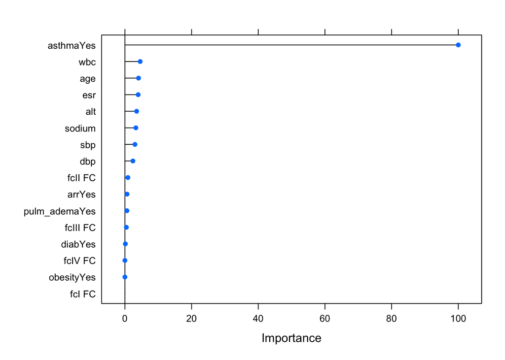

```r
plot(varImp(rf.model))
```

```r
confusionMatrix(rf.model)
```

```
## Cross-Validated (20 fold) Confusion Matrix
##
## (entries are percentual average cell counts across resamples)
##
##           Reference
## Prediction   No  Yes
##        No  97.7  0.0
##        Yes  0.0  2.3
##
##  Accuracy (average) : 1
```

Looking at the results demonstrates that for the three different values of mtry, each mtry value reported an accuracy value of 1 and a kappa value of 1. Looking at variable importance demonstrates that Asthma as the standout variable. This can also be observed in the generated plot. Finally, running a confusion matrix shows that the accuracy value for the random forest model from the training data set is also 1.0.

### Comparing models

The following accuracy valuse were obtained from the training data set for the two models: * Elastic net: 1.0 * Random forest: 1.0

Since both the elastic net model and the random forest model resulted in a accuracy value of 1, we can conclude that neither model is superior to the other. Therefore, either model can be used to be fed into the testing data. We select the elastic net model.

## Part 3: Final model - elastic net

The elastic net model is used to feed into the testing data set through the `predict` function and the final evaluation metrics are determined through generating a confusion matrix.

```r
set.seed(123)

en.pred = en.model %>%
  predict(mi_test)

postResample(en.pred, mi_test$readmission) %>%
  knitr::kable()
```

|  | x |
| --- | --- |
| Accuracy | 1 |
| Kappa | 1 |

```r
confusionMatrix(en.pred, mi_test$readmission)
```

```
## Confusion Matrix and Statistics
##
##           Reference
## Prediction  No Yes
##        No  498   0
##        Yes   0  11
##
##                Accuracy : 1
##                  95% CI : (0.9928, 1)
##     No Information Rate : 0.9784
##     P-Value [Acc > NIR] : 1.48e-05
##
##                   Kappa : 1
##
##  Mcnemar's Test P-Value : NA
##
##             Sensitivity : 1.0000
##             Specificity : 1.0000
##          Pos Pred Value : 1.0000
##          Neg Pred Value : 1.0000
##              Prevalence : 0.9784
##          Detection Rate : 0.9784
##    Detection Prevalence : 0.9784
##       Balanced Accuracy : 1.0000
##
##        'Positive' Class : No
##
```

The confusion matrix reports an accuracy of 1.0 (95% CI: 0.9928, 1) and a kappa value of 1. The model’s p-value is 1.48e-05 with a sensitivity of 1.0000 and a specificity of 1.0000. The reporetd PPV is 1.0000, the reported NPV is 1.0000, and the prevalence is 0.9784.